# transition_statesの機能

[@anemptyarchive](https://www.anarchive-beta.com/)

2022/03/25

# transition_states

`gganimate`パッケージの関数`transition_states()`について解説します。`transition_states()`は、アニメーション(gif画像)のフレーム切り替えを制御します。

利用するパッケージを読み込みます。

```r
# 利用するパッケージ
library(ggplot2)
library(gganimate)
```

基本的に`パッケージ名::関数名()`の記法で書きます。ただし作図コードに関してはごちゃごちゃしてしまうので、`ggplot2`パッケージの関数は関数名のみで、`gganimate`パッケージの関数はパッケージ名を明示して書きます。

## データフレームの作成

まずは、作図に利用するデータフレームを作成します。

```r
# データフレームを作成
df <- tibble::tibble(
  x = 0:5,
  y = 0:5,
  state = 0:5
)
df
```

```
## # A tibble: 6 x 3
##       x     y state
##   <int> <int> <int>
## 1     0     0     0
## 2     1     1     1
## 3     2     2     2
## 4     3     3     3
## 5     4     4     4
## 6     5     5     5
```

分かりやすい値を作成しておきます。`tibble::tibble()`を使ってデータフレームを作成していますが、`data.frame()`を使っても問題ありません。

`transition_states()`の状態(データ)の引数`states`(第1引数)に、フレームの順序を示す列を指定します。この例では、`state`列が対応します。

このデータを用いた散布図と棒グラフのアニメーションを通じて、`transition_states()`の機能を確認していきます。

## 散布図の場合

散布図に対して`transition_states()`を利用します。

全てのデータを散布図で確認しておきます。

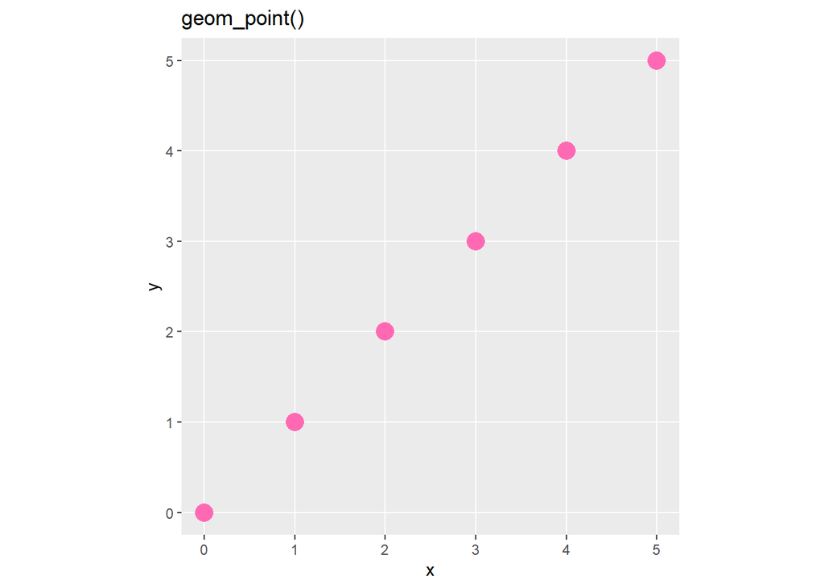

```r
# 散布図を作成
ggplot(df, aes(x = x, y = y)) +
  geom_point(size = 5, color = "hotpink") + # 散布図
  scale_x_continuous(breaks = df[["x"]], minor_breaks = FALSE) + # x軸目盛
  scale_y_continuous(breaks = df[["y"]], minor_breaks = FALSE) + # y軸目盛
  coord_fixed(ratio = 1) + # アスペクト比
  labs(title = "geom_point()")
```

点$(x, y)$について、$(0, 0)$から$(5, 5)$までの6個の点が実際のデータであり、この点を辿るようにグラフが変化します。

### ラベル変数

`transition_states()`で使える4つのラベル変数(`previous_state`・`closest_state`・`next_state`・`transitioning`)を確認します。

ラベル変数名を`{}`で挟んだ文字列を`labs()`などに指定します。

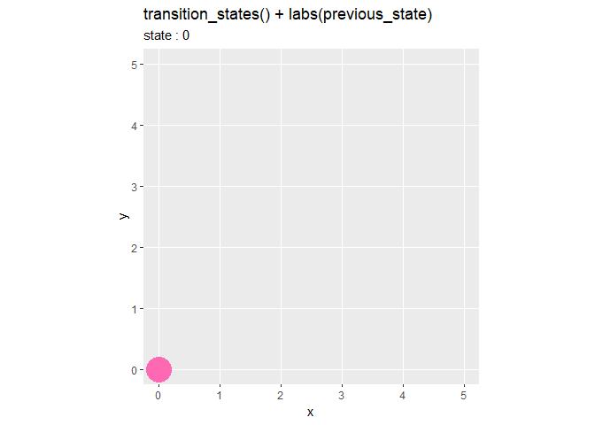

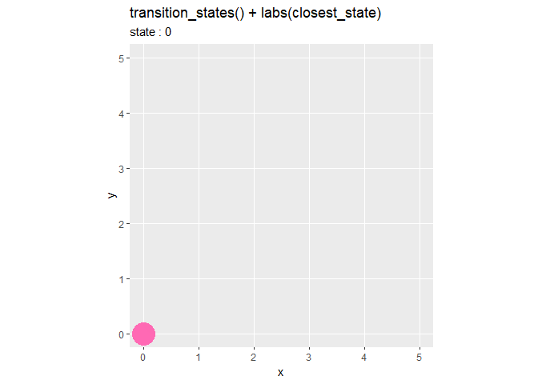

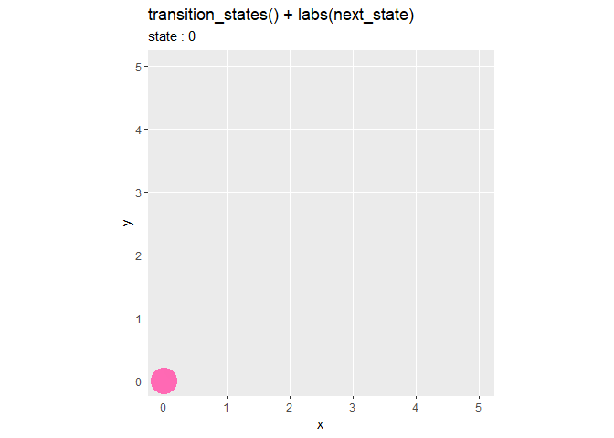

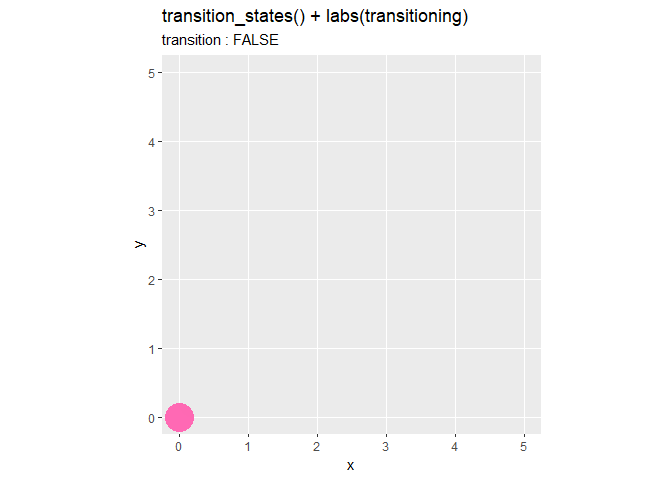

```r
# ラベル変数を指定
lv <- "previous_state" # 前のデータの値
#lv <- "closest_state"  # 近いデータの値
#lv <- "next_state"     # 次のデータの値
#lv <- "transitioning"  # 遷移中かどうか

# ラベル変数の設定
anim <- ggplot(df, aes(x = x, y = y)) +
  geom_point(size = 10, color = "hotpink") + # 散布図
  gganimate::transition_states(states = state) + # フレーム
  scale_x_continuous(breaks = df[["x"]], minor_breaks = FALSE) + # x軸目盛
  scale_y_continuous(breaks = df[["y"]], minor_breaks = FALSE) + # y軸目盛
  coord_fixed(ratio = 1) + # アスペクト比
  labs(title = paste0("transition_states() + labs(", lv, ")"),
       subtitle = paste0("state : {", lv, "}"))

# gif画像を作成
gganimate::animate(plot = anim, nframes = 60, fps = 6)
```

`"{previous_state}"`は、前のデータ(状態)の値に置き換わります。ピンク色の点が次のデータ(状態)に辿り着いたタイミングで値が変わるのが分かります。  
`"{closest_state}"`は、近いデータの値になります。前後のデータの中心で値が変わるのが分かります。  
`"{next_state}"`は、次のデータの値になります。点が現在のデータから動き出したタイミングで値が変わるのが分かります。  
`"{transitioning}"`は、遷移中かどうかを論理値で表します。データ間を遷移中であれば`TRUE`、データ上の点であれば`FALSE`になります。(`transitioning`のグラフについてはサブタイトルのコードを書き替えました。)

解説用に複雑な作図コードになっていますが、`title = "{closest_state}"`のように指定してください。

### 引数

`transition_length`引数は、データ間の遷移の相対的な長さを数値で指定します。「相対的」については後で確認します。

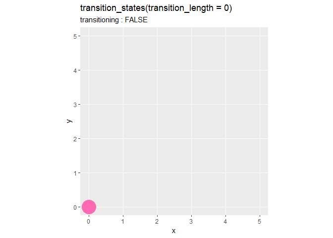

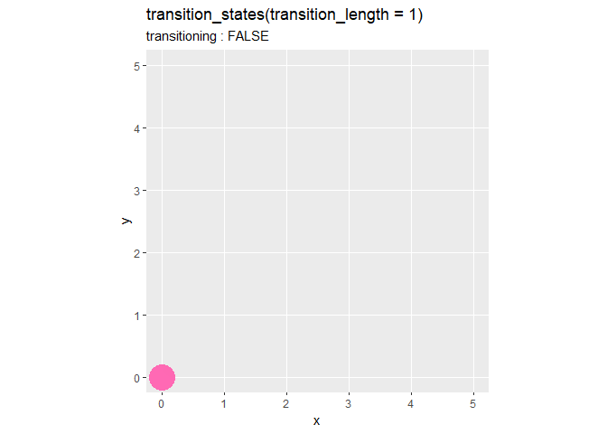

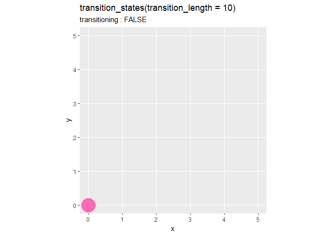

```r
# 値を指定:(デフォルト:1)
tl <- 0

# transition_length(データ間の遷移)の設定
anim <- ggplot(df, aes(x = x, y = y)) +
  geom_point(size = 10, color = "hotpink") + # 散布図
  gganimate::transition_states(states = state, transition_length = tl, wrap = FALSE) + # フレーム
  scale_x_continuous(breaks = df[["x"]], minor_breaks = FALSE) + # x軸目盛
  scale_y_continuous(breaks = df[["y"]], minor_breaks = FALSE) + # y軸目盛
  coord_fixed(ratio = 1) + # アスペクト比
  labs(title = paste0("transition_states(transition_length = ", tl, ")"),
       subtitle = "transitioning : {transitioning}")

# gif画像を作成
gganimate::animate(plot = anim, nframes = 60, fps = 6)
```

デフォルトは`1`です。値が大きいほど遷移時間が長くなり、データ間を細かく補完します。値が大きい(遷移時間が長い)と、データ点上での停止時間が短くなり、全体の時間(フレーム数)は変わりません。`0`のとき、途中経過を描画せずにデータ点上を移っているのが分かります。

複数の値をベクトルで指定することで、データごとに設定できます。

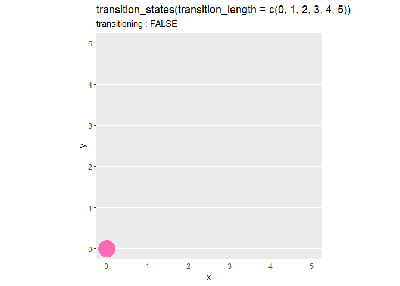

```r
# 値を指定:(デフォルト:1)
tl <- 0:5

# transition_length(データ間の遷移)の設定
anim <- ggplot(df, aes(x = x, y = y)) +
  geom_point(size = 10, color = "hotpink") + # 散布図
  gganimate::transition_states(states = state, transition_length = tl, wrap = FALSE) + # フレーム
  scale_x_continuous(breaks = df[["x"]], minor_breaks = FALSE) + # x軸目盛
  scale_y_continuous(breaks = df[["y"]], minor_breaks = FALSE) + # y軸目盛
  coord_fixed(ratio = 1) + # アスペクト比
  labs(title = paste0("transition_states(transition_length = c(", paste0(tl, collapse = ", "), "))"),
       subtitle = "transitioning : {transitioning}")

# gif画像を作成
gganimate::animate(plot = anim, nframes = 60, fps = 6)
```

遷移の度に値が大きくなるように指定しました。よって、データが移るごとに途中経過が細かく(遷移時間が長く)なっているのが分かります。

`state_length`引数は、データ点における停止時間の相対的な長さを数値で指定します。

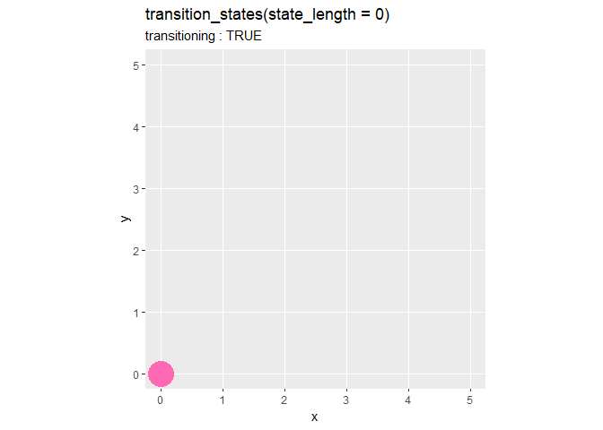

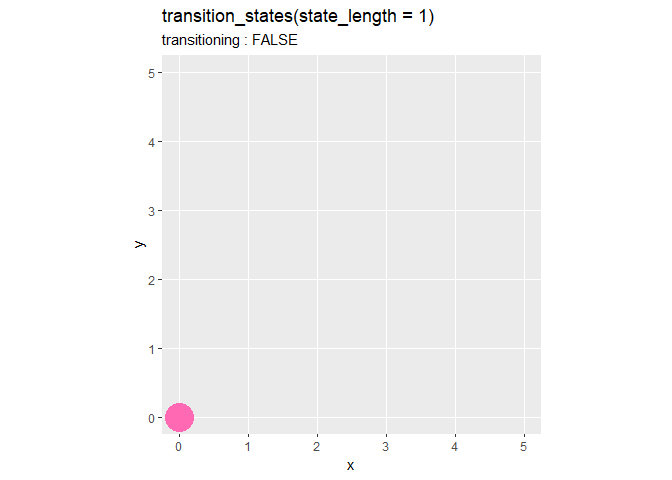

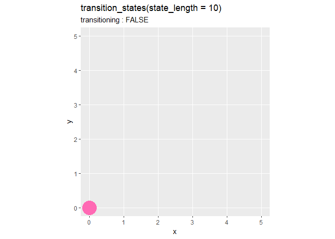

```r
# 値を指定:(デフォルト:1)
sl <- 0

# state_length(データ点での一時停止)の設定
anim <- ggplot(df, aes(x = x, y = y)) +
  geom_point(size = 10, color = "hotpink") + # 散布図
  gganimate::transition_states(states = state, state_length = sl, wrap = FALSE) + # フレーム
  scale_x_continuous(breaks = df[["x"]], minor_breaks = FALSE) + # x軸目盛
  scale_y_continuous(breaks = df[["y"]], minor_breaks = FALSE) + # y軸目盛
  coord_fixed(ratio = 1) + # アスペクト比
  labs(title = paste0("transition_states(state_length = ", sl, ")"),
       subtitle = "transitioning : {transitioning}")

# gif画像を作成
gganimate::animate(plot = anim, nframes = 60, fps = 6)
```

デフォルトは`1`です。値が大きいほど一時停止の時間が長くなります。値が大きい(停止時間が長い)と、データ間の遷移時間が短く(補完が粗く)なり、全体の時間(フレーム数)は変わりません。`0`のとき、一時停止せずに同じスピードで変化しているのが分かります。

こちらも、ベクトルで指定できます。

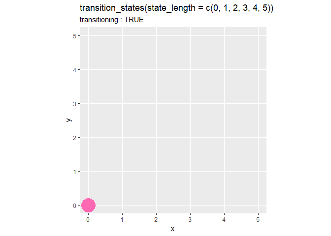

```r
# 値を指定:(デフォルト:1)
sl <- 0:5

# state_length(データ点での一時停止)の設定
anim <- ggplot(df, aes(x = x, y = y)) +
  geom_point(size = 10, color = "hotpink") + # 散布図
  gganimate::transition_states(states = state, state_length = sl, wrap = FALSE) + # フレーム
  scale_x_continuous(breaks = df[["x"]], minor_breaks = FALSE) + # x軸目盛
  scale_y_continuous(breaks = df[["y"]], minor_breaks = FALSE) + # y軸目盛
  coord_fixed(ratio = 1) + # アスペクト比
  labs(title = paste0("transition_states(state_length = c(", paste0(sl, collapse = ", "), "))"),
       subtitle = "transitioning : {transitioning}")

# gif画像を作成
gganimate::animate(plot = anim, nframes = 60, fps = 6)
```

遷移の度に値が大きくなるように指定しました。よって、データが移るごとに停止時間が長くなっているのが分かります。

2つの引数の関係を確認します。

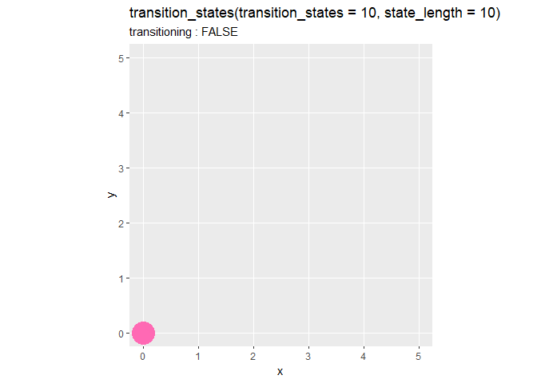

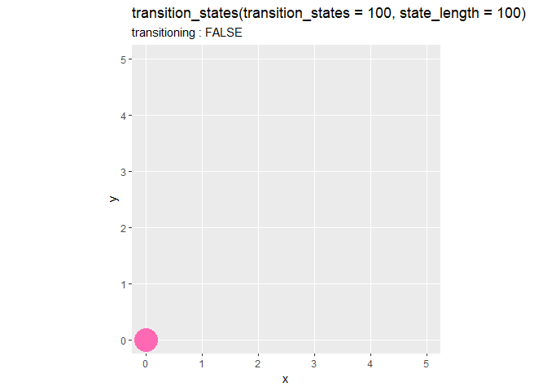

```r
# 値を指定:(デフォルト:1)
tl <- 10
sl <- 10

# state_length(データ点での一時停止)の設定
anim <- ggplot(df, aes(x = x, y = y)) +
  geom_point(size = 10, color = "hotpink") + # 散布図
  gganimate::transition_states(states = state, transition_length = tl, state_length = sl, wrap = FALSE) + # フレーム
  scale_x_continuous(breaks = df[["x"]], minor_breaks = FALSE) + # x軸目盛
  scale_y_continuous(breaks = df[["y"]], minor_breaks = FALSE) + # y軸目盛
  coord_fixed(ratio = 1) + # アスペクト比
  labs(title = paste0("transition_states(transition_states = ", tl, ", state_length = ", sl, ")"),
       subtitle = "transitioning : {transitioning}")

# gif画像を作成
gganimate::animate(plot = anim, nframes = 60, fps = 6)
```

`transition_length`と`state_length`は、それぞれ遷移と停止の時間を設定しますが、互いの値の大きさに影響します。2つの引数が同じ値であれば、値の大小が影響していないのが分かります。それぞれの値の比率に応じて、フレーム数が割り当てられます。  
アニメーション全体のフレーム数は、gif画像のレンダリング関数`animate()`のフレーム数の引数`nframes`で指定できます。デフォルト`100`です。

`wrap`引数は、最後のデータと最初のデータの間で遷移するかを論理値で指定します。

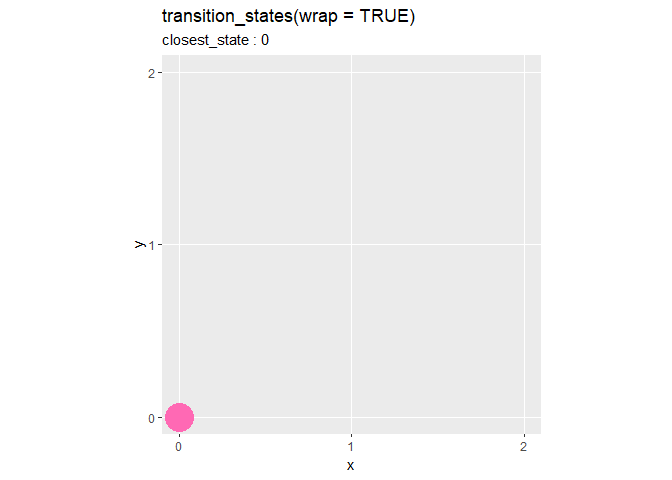

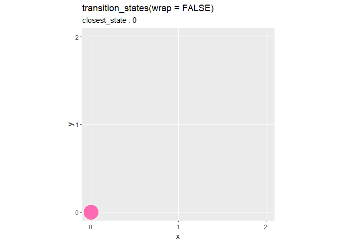

```r
# 論理値を指定:(デフォルト:TRUE)
b <- TRUE
#b <- FALSE

# wrap(最後のデータと最初のデータの遷移)の設定
anim <- ggplot(head(df, 3), aes(x = x, y = y)) +
  geom_point(size = 10, color = "hotpink") + # 散布図
  gganimate::transition_states(states = state, wrap = b) + # フレーム
  scale_x_continuous(breaks = df[["x"]], minor_breaks = FALSE) + # x軸目盛
  scale_y_continuous(breaks = df[["y"]], minor_breaks = FALSE) + # y軸目盛
  coord_fixed(ratio = 1) + # アスペクト比
  labs(title = paste0("transition_states(wrap = ", b, ")"),
       subtitle = "closest_state : {closest_state}")

# gif画像を作成
gganimate::animate(plot = anim, nframes = 30, fps = 10)
```

デフォルトは`TRUE`で、最後のデータから最初のデータへ遷移(データ間を補完するグラフを描画)します。`FALSE`を指定すると、最後のデータに辿り着くとグラフの描画が終わり、gif画像のループによって最初のデータのグラフに戻ります。  
点$(2, 2)$から点$(0, 0)$にピンク色の点が戻る際に、間が補完されて描画されているのが分かります。

## 棒グラフの場合

次は、棒グラフに対して`transition_states()`を利用します。

全てのデータを棒グラフで確認しておきます。

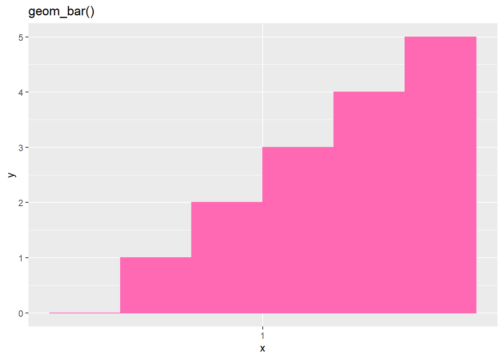

```r
# 棒グラフを作成
ggplot(df, aes(x = 1, y = y, group = y)) +
  geom_bar(stat = "identity", position = "dodge", fill = "hotpink", color = "hotpink") + # 棒グラフ
  scale_x_continuous(breaks = 1, minor_breaks = FALSE) + # x軸目盛
  labs(title = "geom_bar()",
       fill = "y", color = "y")
```

x軸の値を`1`で固定して、y軸の変化をアニメーションで可視化します。

### ラベル変数

散布図のときと同様に、4つのラベル変数を使ってみます。

[figure not shown]

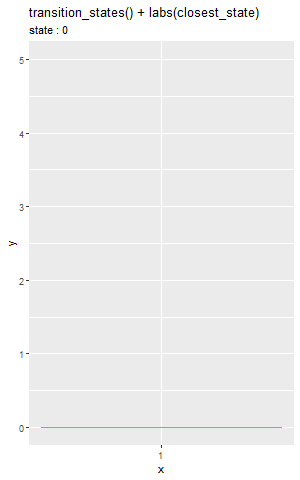

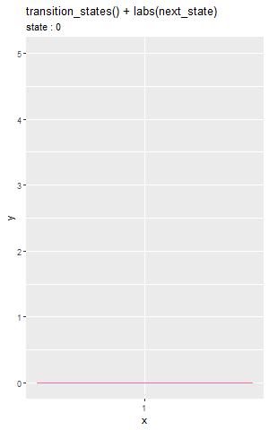

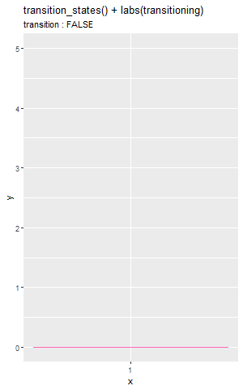

```r
# ラベル変数を指定
lv <- "previous_state" # 前のデータの値
lv <- "closest_state"  # 近いデータの値
lv <- "next_state"     # 次のデータの値
lv <- "transitioning"  # 遷移中かどうか

# ラベル変数の設定
anim <- ggplot(df, aes(x = 1, y = y)) +
  geom_bar(stat = "identity", fill = "hotpink", color = "hotpink") + # 棒グラフ
  gganimate::transition_states(states = state) + # フレーム
  scale_x_continuous(breaks = 1, minor_breaks = FALSE) + # x軸目盛
  labs(title = paste0("transition_states() + labs(", lv, ")"),
       subtitle = paste0("state : {", lv, "}"))

# gif画像を作成
gganimate::animate(plot = anim, nframes = 120, fps = 12, width = 300)
```

ラベル変数は、グラフによらず機能します。

### 引数

`transition_length`引数を使って、遷移時間を設定します。

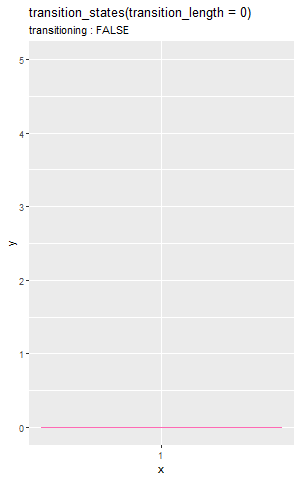

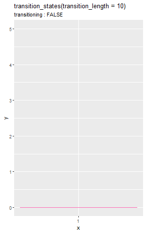

```r
# 値を指定:(デフォルト:1)
tl <- 0

# transition_length(データ間の遷移)の設定
anim <- ggplot(df, aes(x = 1, y = y)) +
  geom_bar(stat = "identity", fill = "hotpink", color = "hotpink") + # 棒グラフ
  gganimate::transition_states(states = state, transition_length = tl, wrap = FALSE) + # フレーム
  scale_x_continuous(breaks = 1, minor_breaks = FALSE) + # x軸目盛
  labs(title = paste0("transition_states(transition_length = ", tl, ")"),
       subtitle = "transitioning : {transitioning}")

# gif画像を作成
gganimate::animate(plot = anim, nframes = 120, fps = 12, width = 300)
```

デフォルトの設定はラベル変数のときと同じなので省略します。値が大きいほど遷移時間が長く、データ間を細かく補完し、データ上での停止時間が短くなります。

`state_length`引数を使って、一時停止時間を設定します。

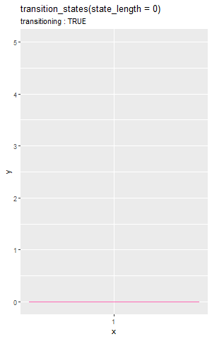

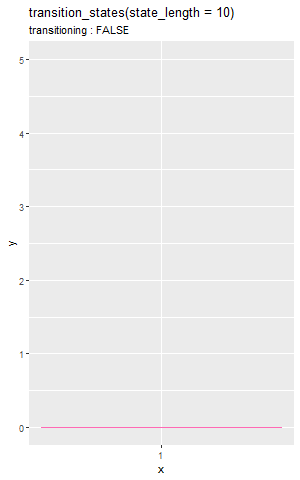

```r
# 値を指定:(デフォルト:1)
sl <- 0

# state_length(データ点での一時停止)の設定
anim <- ggplot(df, aes(x = 1, y = y)) +
  geom_bar(stat = "identity", fill = "hotpink", color = "hotpink") + # 棒グラフ
  gganimate::transition_states(states = state, state_length = sl, wrap = FALSE) + # フレーム
  scale_x_continuous(breaks = 1, minor_breaks = FALSE) + # x軸目盛
  labs(title = paste0("transition_states(state_length = ", sl, ")"),
       subtitle = "transitioning : {transitioning}")

# gif画像を作成
gganimate::animate(plot = anim, nframes = 120, fps = 12, width = 300)
```

デフォルトの設定はラベル変数のときと同じなので省略します。値が大きいほどデータ点での一時停止が長く、データ間の補完が粗くなります。

`wrap`引数を使って、ループの繋ぎ方を設定します。

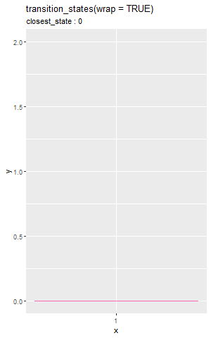

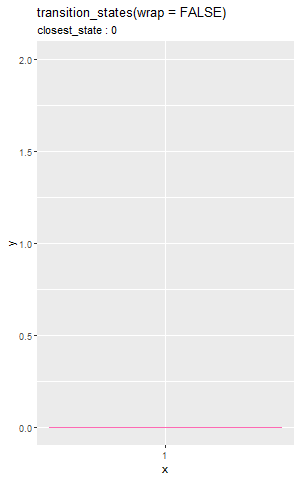

```r
# 論理値を指定:(デフォルト:TRUE)
b <- TRUE
#b <- FALSE

# wrap(最後のデータと最初のデータの遷移)の設定
anim <- ggplot(head(df, 3), aes(x = 1, y = y)) +
  geom_bar(stat = "identity", fill = "hotpink", color = "hotpink") + # 棒グラフ
  gganimate::transition_states(states = state, wrap = b) +  # フレーム
  scale_x_continuous(breaks = 1, minor_breaks = FALSE) + # x軸目盛
  labs(title = paste0("transition_states(wrap = ", b, ")"),
       subtitle = "closest_state : {closest_state}")

# gif画像を作成
gganimate::animate(plot = anim, nframes = 60, fps = 20, width = 300)
```

デフォルトまたは`TRUE`だと、バーが巻き戻るように最初の値になるのが分かります。

ここまではx軸を`1`で固定していました。x軸に`x`列を指定します。

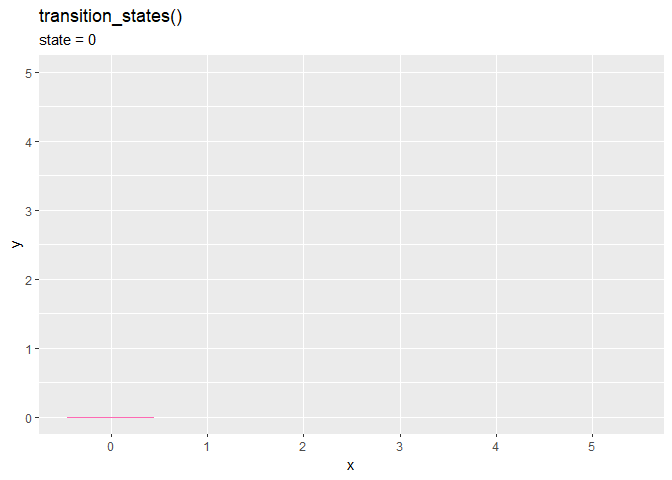

```r
# 2軸方向への変化
anim <- ggplot(df, aes(x = x, y = y)) +
  geom_bar(stat = "identity", fill = "hotpink", color = "hotpink") + # 棒グラフ
  gganimate::transition_states(states = state) + # フレーム
  scale_x_continuous(breaks = df[["x"]], minor_breaks = FALSE) + # x軸目盛
  labs(title = paste0("transition_states()"),
       subtitle = "state = {closest_state}")

# gif画像を作成
gganimate::animate(plot = anim, nframes = 120, fps = 12)
```

`state`列と`x`列の値に従って、x軸も移動します。

以上で、ラベル変数と引数の機能を確認できました。次は、実用を想定してグラフを作成します。

## 利用例：サイコロ

`gganimate`パッケージの使用例として、サイコロの出目の頻度を2つのグラフで可視化します。

利用するパッケージを読み込みます。

```r
# 利用するパッケージ
library(tidyverse)
library(gganimate)
```

### データの生成

まずは、利用するデータを作成します。

```r
# 試行回数を指定
N <- 30

# 面の数を指定
V <- 6

# サイコロを振る
result_mat <- rmultinom(n = N, size = 1, prob = rep(1 / V, times = V)) %>%
  t()
result_mat[1:5, ]
```

```
##      [,1] [,2] [,3] [,4] [,5] [,6]
## [1,]    0    0    0    1    0    0
## [2,]    0    0    0    1    0    0
## [3,]    0    0    0    0    0    1
## [4,]    0    0    1    0    0    0
## [5,]    0    0    0    1    0    0
```

`rmultinom()`の出力を`t()`で転置しておきます。行が各試行、列が各面に対応しており、値が`1`の列番号が出た目を表します。

出目の値を抽出します。

```r
# 出目を抽出
result_vec <- which(t(result_mat) == 1, arr.ind = TRUE)[, "row"]
result_vec[1:5]
```

```
## [1] 4 4 6 3 4
```

`result_mat`に対して、値が`1`の列番号を抽出します。  
`which()`は、条件に合う要素の行番号と列番号を返します。`result_mat`を転置して渡す必要があります。転置するので、行番号(`"row"`列)を取り出します。

サイコロを振った結果が得られたので、アニメーションで可視化していきます。

### 棒グラフによる可視化

各出目の出現回数を棒グラフ、各試行の出目を散布図で可視化します。

試行回数と出た目の値をデータフレームに格納します。

```r
# 結果を格納
result_df <- tibble::tibble(
  v = c(NA_integer_, result_vec),
  n = 0:N
)
head(result_df)
```

```
## # A tibble: 6 x 2
##       v     n
##   <int> <int>
## 1    NA     0
## 2     4     1
## 3     4     2
## 4     6     3
## 5     3     4
## 6     4     5
```

グラフの変化を分かりやすくするために、0回目の結果に相当する行を追加します。出目はないので(整数型の)欠損値`NA_integer_`を使います。

各試行までに出た目の数をそれぞれカウントします。

```r
# 出目を集計
count_df <- result_mat %>%
  tibble::as_tibble() %>% # データフレームに変換
  cumsum() %>% # 試行ごとに集計
  dplyr::mutate(n = 1:N) %>% # 試行回数列を追加
  tidyr::pivot_longer(
    cols = -n,
    names_to = "v",
    names_prefix = "V",
    names_ptypes = list(v = factor()),
    values_to = "count"
  ) %>% # 縦型のデータフレームに変換
  rbind(
    tibble::tibble(
      n = rep(0, times = V),
      v = factor(1:V),
      count = rep(0, times = V)
    ),
    .
  ) # 0回目の結果を追加

# 1回から3回目時点の結果
count_df %>%
  dplyr::filter(n >= 1, n <= 3)
```

```
## # A tibble: 18 x 3
##        n v     count
##    <dbl> <fct> <dbl>
##  1     1 1         0
##  2     1 2         0
##  3     1 3         0
##  4     1 4         1
##  5     1 5         0
##  6     1 6         0
##  7     2 1         0
##  8     2 2         0
##  9     2 3         0
## 10     2 4         2
## 11     2 5         0
## 12     2 6         0
## 13     3 1         0
## 14     3 2         0
## 15     3 3         0
## 16     3 4         2
## 17     3 5         0
## 18     3 6         1
```

`cumsum()`で累積和(`1`行目から`n`行目までの和)を計算します。  
最後にこちらも、0回目の結果に相当する行(`V`行のデータフレーム)を追加します。

棒グラフと散布図を重ねて描画します。

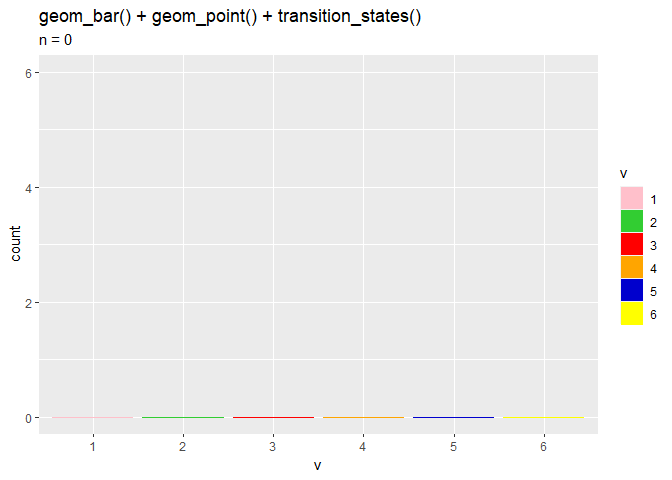

```r
# 遷移の数を指定
d <- 10

# 棒グラフを作成
anim <- ggplot() +
  geom_bar(data = count_df, mapping = aes(x = v, y = count, fill = v, color = v),
           stat = "identity") + # 棒グラフ
  geom_point(data = result_df, mapping = aes(x = v, y = 0),
             color = "hotpink", size = 5) + # 散布図
  gganimate::transition_states(states = n, transition_length = d) +
  scale_fill_manual(values = c("pink", "limegreen", "red", "orange", "mediumblue", "yellow")) + # バーの色:(不必要)
  scale_color_manual(values = c("pink", "limegreen", "red", "orange", "mediumblue", "yellow")) + # 枠線の色:(不必要)
  labs(title = "geom_bar() + geom_point() + transition_states()",
       subtitle = "n = {closest_state}")

# gif画像を作成
gganimate::animate(plot = anim, nframes = N*d, fps = d)
```

`transition_states()`の第1引数に試行回数`n`列を指定して、試行ごとにグラフを描画します。